# Time Series Models

#### Fit SARIMA Without Giving Model Orders

We can use the `auto.arima()` function from the `forecast` package and set `seasonal = TRUE` to ask R to return the best ARIMA/SARIMA model according to either AIC, AICc or BIC value.

```r
rm(list=ls()) # clear workspace
cat("\014")  # clear console
```

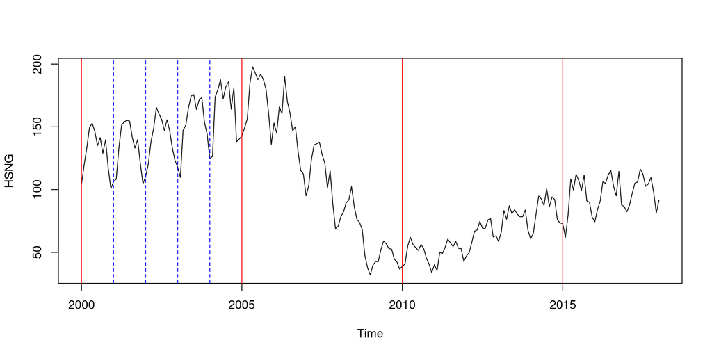

```r
library(Quandl)
Quandl_key = read.csv("quandlkey.csv",stringsAsFactors=FALSE)$Key
Quandl.api_key(Quandl_key)
startd<-"2000-01-01"
endd<-"2018-01-01"
ticker <- "FRED/HOUSTNSA" #New Privately-Owned Housing Units Started: Total Units
HSNG <- Quandl(ticker, type="ts",start_date=startd, end_date=endd)
{plot(HSNG)
abline(v = ts(c(2000,2005,2010,2015)),col = "red") # v is for vertical lines
abline(v = ts(c(2001,2002,2003,2004)), col = "blue", lty = 2)}
```

```r
# Evidence of seasonality


### Fit SARIMA Model
library(forecast)
auto.arima(HSNG, seasonal = TRUE)
```

```
## Series: HSNG
## ARIMA(1,1,1)(0,1,2)[12]
##
## Coefficients:
##           ar1      ma1     sma1     sma2
##       -0.2223  -0.3329  -0.6617  -0.1001
## s.e.   0.1168   0.1079   0.0783   0.0768
##
## sigma^2 = 77.14:  log likelihood = -735.63
## AIC=1481.27   AICc=1481.57   BIC=1497.86
```

```r
# We have a model with ARIMA order (p=1,d=1,q=1), seasonal order (P=0,D=1,Q=2), and seasonal lag S=12
```

### Examine Model Residual

```r
rm(list=ls()) # clear workspace
cat("\014")  # clear console
```

```r
library(Quandl)
Quandl_key = read.csv("quandlkey.csv",stringsAsFactors=FALSE)$Key
Quandl.api_key(Quandl_key)
startd<-"1990-01-01"
endd<-"2018-01-01"
freq<-"quarterly"
GDP <- Quandl("FRED/GDPC1", type="xts",start_date=startd, end_date=endd)
GDPGrowth <- diff(log(GDP)) # calculate log growth rate
GDPGrowth <- na.omit(GDPGrowth) # get rid of the NAs

library(forecast)
fit <- auto.arima(GDPGrowth)
fit
```

```
## Series: GDPGrowth
## ARIMA(2,0,0) with non-zero mean
##
## Coefficients:
##          ar1     ar2   mean
##       0.3292  0.1861  0.006
## s.e.  0.0921  0.0924  0.001
##
## sigma^2 = 2.89e-05:  log likelihood = 427.76
## AIC=-847.52   AICc=-847.15   BIC=-836.65
```

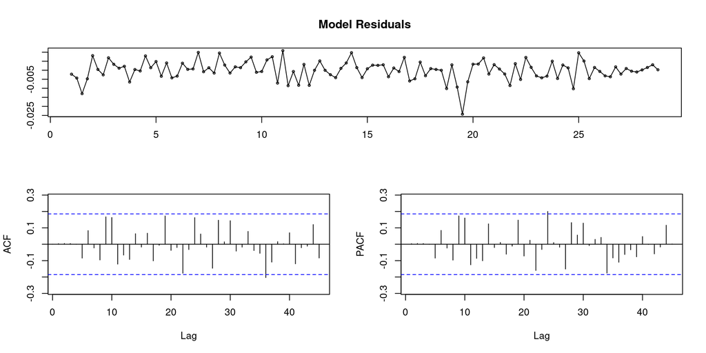

```r
### Ensure errors white noise.
# Ideally, residuals should look like white noise, meaning they are
# normally distributed.
# We will use tsdisplay to check the residuals for our optimal model.
tsdisplay(residuals(fit), lag.max=45, main='Model Residuals')
```

```r
# Interpret: The ACF and PACF indicate little to no persistence.  The time series plot shows little remaining patterns
# to the data.
```

### Ljung–Box-Residual Indep.

```r
rm(list=ls()) # clear workspace
cat("\014")  # clear console
```

```r
library(Quandl)
Quandl_key = read.csv("quandlkey.csv",stringsAsFactors=FALSE)$Key
Quandl.api_key(Quandl_key)
startd<-"1990-01-01"
endd<-"2018-01-01"
freq<-"quarterly"
GDP <- Quandl("FRED/GDPC1", type="xts",start_date=startd, end_date=endd)
GDPGrowth <- diff(log(GDP)) # calculate log growth rate
GDPGrowth <- na.omit(GDPGrowth) # get rid of the NAs

library(forecast)
fit <- auto.arima(GDPGrowth)
fit
```

```
## Series: GDPGrowth
## ARIMA(2,0,0) with non-zero mean
##
## Coefficients:
##          ar1     ar2   mean
##       0.3292  0.1861  0.006
## s.e.  0.0921  0.0924  0.001
##
## sigma^2 = 2.89e-05:  log likelihood = 427.76
## AIC=-847.52   AICc=-847.15   BIC=-836.65
```

```r
### Compute the Ljung–Box test statistic for examining the null hypothesis of independence in a given time series.
Box.test(residuals(fit),lag=4,type="Ljung")
```

```
##
##  Box-Ljung test
##
## data:  residuals(fit)
## X-squared = 0.0055806, df = 4, p-value = 1
```

```r
# Ho: No autocorrelation
#Interpret: Given the high p-value, we fail to reject the null of no persistence through 4 lags.
```

### Kolmogorov-Smirnov Test

```r
rm(list=ls()) # clear workspace
cat("\014")  # clear console
```

```r
library(Quandl)
Quandl_key = read.csv("quandlkey.csv",stringsAsFactors=FALSE)$Key
Quandl.api_key(Quandl_key)
startd<-"1990-01-01"
endd<-"2018-01-01"
freq<-"quarterly"
GDP <- Quandl("FRED/GDPC1", type="xts",start_date=startd, end_date=endd)
GDPGrowth <- diff(log(GDP)) # calculate log growth rate
GDPGrowth <- na.omit(GDPGrowth) # get rid of the NAs

library(forecast)
fit <- auto.arima(GDPGrowth)
fit
```

```
## Series: GDPGrowth
## ARIMA(2,0,0) with non-zero mean
##
## Coefficients:
##          ar1     ar2   mean
##       0.3292  0.1861  0.006
## s.e.  0.0921  0.0924  0.001
##
## sigma^2 = 2.89e-05:  log likelihood = 427.76
## AIC=-847.52   AICc=-847.15   BIC=-836.65
```

```r
### Let's also test the null of normal distribution via a KS test
ks.test(residuals(fit),pnorm)
```

```
##
##  One-sample Kolmogorov-Smirnov test
##
## data:  residuals(fit)
## D = 0.49566, p-value < 2.2e-16
## alternative hypothesis: two-sided
```

```r
#Interpret: Given the low pvalue, we reject the null, implying that the residuals aren't normally distributed
```

### Quantile-Quantile Plot

```r
rm(list=ls()) # clear workspace
cat("\014")  # clear console
```

```r
library(Quandl)
Quandl_key = read.csv("quandlkey.csv",stringsAsFactors=FALSE)$Key
Quandl.api_key(Quandl_key)
startd<-"1990-01-01"
endd<-"2018-01-01"
freq<-"quarterly"
GDP <- Quandl("FRED/GDPC1", type="xts",start_date=startd, end_date=endd)
GDPGrowth <- diff(log(GDP)) # calculate log growth rate
GDPGrowth <- na.omit(GDPGrowth) # get rid of the NAs

library(forecast)
fit <- auto.arima(GDPGrowth)
fit
```

```
## Series: GDPGrowth
## ARIMA(2,0,0) with non-zero mean
##
## Coefficients:
##          ar1     ar2   mean
##       0.3292  0.1861  0.006
## s.e.  0.0921  0.0924  0.001
##
## sigma^2 = 2.89e-05:  log likelihood = 427.76
## AIC=-847.52   AICc=-847.15   BIC=-836.65
```

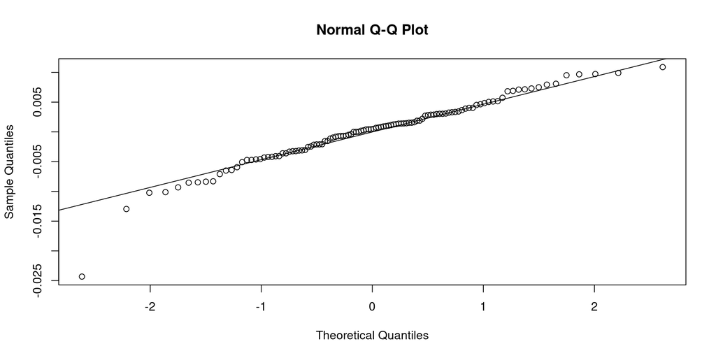

```r
### Let's see if the residuals look like a normal distribution with a qq plot
qqnorm(residuals(fit));
qqline(residuals(fit))
```

### Model Comparison

```r
rm(list=ls()) # clear workspace
cat("\014")  # clear console
```

```r
library(Quandl)
Quandl_key = read.csv("quandlkey.csv",stringsAsFactors=FALSE)$Key
Quandl.api_key(Quandl_key)
startd<-"1990-01-01"
endd<-"2018-01-01"
freq<-"quarterly"
GDP <- Quandl("FRED/GDPC1", type="xts",start_date=startd, end_date=endd)
GDPGrowth <- diff(log(GDP)) # calculate log growth rate
GDPGrowth <- na.omit(GDPGrowth) # get rid of the NAs
```

```r
library(forecast)
Model1<-Arima(GDPGrowth, order = c(1, 0, 0)) # fit an AR(1) model
Model1
```

```
## Series: GDPGrowth
## ARIMA(1,0,0) with non-zero mean
##
## Coefficients:
##          ar1   mean
##       0.4050  6e-03
## s.e.  0.0858  9e-04
##
## sigma^2 = 2.97e-05:  log likelihood = 425.77
## AIC=-845.54   AICc=-845.32   BIC=-837.39
```

```r
Model2<-Arima(GDPGrowth, order = c(0, 0, 3)) # fit an MA(3) model
Model2
```

```
## Series: GDPGrowth
## ARIMA(0,0,3) with non-zero mean
##
## Coefficients:
##          ma1     ma2     ma3    mean
##       0.3227  0.2925  0.1340  0.0061
## s.e.  0.0921  0.0957  0.0816  0.0009
##
## sigma^2 = 2.937e-05:  log likelihood = 427.39
## AIC=-844.78   AICc=-844.21   BIC=-831.18
```

### Test for ARCH Effect

ARCH effect is concerned with a relationship within the heteroskedasticity, often termed serial correlation of the heteroskedasticity.

```r
rm(list=ls()) # clear workspace
cat("\014")  # clear console
```

```r
library(Quandl)
Quandl_key = read.csv("quandlkey.csv",stringsAsFactors=FALSE)$Key
Quandl.api_key(Quandl_key)
startd<-"2010-01-01" #We want from Jan2010 forward.
endd<-"2018-01-01"
freq<-"weekly"
trans<-"rdiff" # calculate simple return
ticker <- "WIKI/JPM.11" # we load the JPM closed price data (the 11th column)

JPM <- Quandl(ticker,transform=trans,start_date=startd, end_date=endd, collapse=freq,type="xts") # Careful here.  The `rdiff` provides the simple return.  We should convert to log returns since we are running a regression.
colnames(JPM )[1]="SimpleRet" # Add column name
JPM$LogRet<-log(1+JPM $SimpleRet)
```

The ARCH model assumes that the conditional mean of the error term in a time series model is constant (zero), but its conditional variance is not.

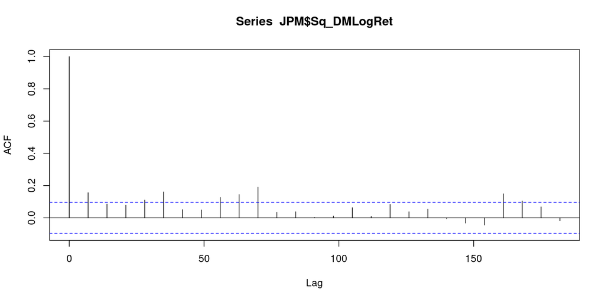

```r
### Get Residual Square
library(dplyr)
reg<-lm(JPM$LogRet~1) # demean the return series by regress it on constant only
JPM$DMLogRet<-resid(reg) # get residuals, which is the de-mean value of log return
JPM$Sq_DMLogRet<-JPM$DMLogRet^2 # let's compute the squared residuals (i.e. JPM$DMLogRet)
acf(JPM$Sq_DMLogRet) # use the ACF to see if there appears to be persistence in the squared residuals
```

```r
### Engle's ARCH LM test
# Engle's ARCH LM test is the most commonly applied standard test to detect autoregressive conditional heteroscedasticity. We start with the regression of squared residuals upon lagged squared residuals
ARCH <- lm(JPM$Sq_DMLogRet~lag.xts(JPM$Sq_DMLogRet,k=1))
summary(ARCH)
```

```
##
## Call:
## lm(formula = JPM$Sq_DMLogRet ~ lag.xts(JPM$Sq_DMLogRet, k = 1))
##
## Residuals:
##        Min         1Q     Median         3Q        Max
## -0.0031486 -0.0009597 -0.0007224  0.0001594  0.0143211
##
## Coefficients:
##                                  Estimate Std. Error t value Pr(>|t|)
## (Intercept)                     0.0009616  0.0001200   8.012 1.17e-14 ***
## lag.xts(JPM$Sq_DMLogRet, k = 1) 0.1558554  0.0486171   3.206  0.00145 **
## ---
## Signif. codes:  0 '***' 0.001 '**' 0.01 '*' 0.05 '.' 0.1 ' ' 1
##
## Residual standard error: 0.002168 on 413 degrees of freedom
##   (1 observation deleted due to missingness)
## Multiple R-squared:  0.02428,    Adjusted R-squared:  0.02192
## F-statistic: 10.28 on 1 and 413 DF,  p-value: 0.001452
```

```r
# Calculate the LM test statistic
library(broom)
RSq_ARCH <- glance(ARCH)[[1]] # grab the R square value of ARCH model
L <- length(JPM$Sq_DMLogRet) # lengths for data
q <- length(coef(ARCH))-1 # degrees of freedom q
LM <- (L-q)*RSq_ARCH # Compute the LM stat as (L-q)*Rsquare
LM
```

```
## [1] 10.07604
```

```r
# Calculate the critical value
alpha <- 0.05 # set significance levels
Critical <- qchisq(1-alpha, q) # get chi-squared stat(the arch test stat is a chi-squared)
Critical
```

```
## [1] 3.841459
```

```r
# Interpret: Null hypothesis is white noise (i.e. no ARCH effects).  Test stat is greater than critical value, so we reject, implying ARCH effects exist.
```